# GeneSetEnrichment

Phoebe

2023-04-26

### March 22, 2023

# Load a SPATA object and subset spata object (spata_obj2) from the SPATA2_Test R file

- spata_obj2 should be subset to include spots from scanpy QC and leiden clusters also from scanpy workflow.

```r
library(SPATA2)
library(magrittr)
library(tidyverse)
library(monocle3)
library(viridisLite)
library(msigdbr)
library(clusterProfiler)

#directory_10X="C:/Users/mzaidi/Documents/Visium Datasets/Sheila_GBM/GBM_datasets/V21004-FF__56_A1" #Need to reverse slashes when copied in Windows
directory_10X="C:/Users/mzaidi/Documents/Visium Datasets/Sheila_GBM/GBM_datasets/50D" #Need to reverse slashes when copied in Windows
#directory_10X="C:/Users/mzaidi/Documents/Visium Datasets/Sheila_GBM/GBM_datasets/16_1" #Need to reverse slashes when copied in Windows
#directory_10X="C:/Users/mzaidi/Documents/Visium Datasets/Sheila_GBM/GBM_datasets/45B"
#directory_10X="C:/Users/mzaidi/Documents/Visium Datasets/Sheila_GBM/GBM_datasets/47"
#directory_10X="C:/Users/mzaidi/Documents/Visium Datasets/Sheila_GBM/GBM_datasets/A1 - 15A"
#directory_10X="C:/Users/mzaidi/Documents/Visium Datasets/Sheila_GBM/GBM_datasets/B1(missing currently) - 19"
#directory_10X="C:/Users/mzaidi/Documents/Visium Datasets/Sheila_GBM/GBM_datasets/C1 - 33B"
#directory_10X="C:/Users/mzaidi/Documents/Visium Datasets/Sheila_GBM/GBM_datasets/D1_-_35"
#directory_10X="C:/Users/mzaidi/Documents/Visium Datasets/Sheila_GBM/GBM_datasets/V21004-FF__60_B1"
#directory_10X="C:/Users/mzaidi/Documents/Visium Datasets/Sheila_GBM/GBM_datasets/V21004-FF__61_C1"
#directory_10X="C:/Users/mzaidi/Documents/Visium Datasets/Sheila_GBM/GBM_datasets/V21004-FF__63_D1"

sample_name <- substr(directory_10X, 67, nchar(directory_10X))
#sample_name="50D"
subdir='SPATA2_figures'
sig_trajectory_subdir='signature_trajectories'
custom_fig_subdir='custom_figures'
directory_genesets="C:/Users/mzaidi/Documents/Visium Datasets/Gene signatures/all_SPATA2_external.csv"
external_geneset=read.csv(directory_genesets)
#Remove empty columns from external_geneset
empty_columns <- colSums(is.na(external_geneset) | external_geneset == "") == nrow(external_geneset)
external_geneset=external_geneset[, !empty_columns]

#create output directory
dir.create(file.path(directory_10X, subdir), showWarnings = FALSE) #create base figure directory
setwd(file.path(directory_10X, subdir))
dir.create(sig_trajectory_subdir, showWarnings = FALSE) #create subdirectory for iterative sig plotting
dir.create(custom_fig_subdir, showWarnings = FALSE) #create subdirectory for iterative sig plotting
# Create directory to read/write spata objects
spata_obj_dir=paste(getwd(),"spata_obj.RDS",sep="/")
spata_obj_dir2=paste(getwd(),"spata_obj2.RDS",sep="/")

spata_obj <- loadSpataObject(spata_obj_dir, verbose = TRUE, update = TRUE)
#adjust directory instructions
spata_obj <-
  adjustDirectoryInstructions(
    object = spata_obj,
    to = "spata_object",
    directory_new = spata_obj_dir, # the directory under which to store the object
  )
spata_obj@used_genesets <-
     dplyr::filter(spata_obj@used_genesets,
                   !ont %in% "external_RonNeftel.MESUnique")
```

These are the colours we use for the leiden clusters because I think they’re pretty. Also, they’re the same ones from Python, so your figures should match :) SPATA2 surface plot functions do NOT like these colours for some reason they want your clrp params to be character values from the ugly-ass colours that they choose to display clusters in. You have to use `clrp_adjust = leiden_gene_colors` as a param in plotting functions if you want it to work.

```r
leiden_gene_colors = c("0"='#1f77b4',
                       "1"='#ff7f0e',
                       "2"='#279e68',
                       "3"='#d62728',
                       "4"='#aa40fc',
                       "5"='#8c564b',
                       "6"= '#e377c2',
                       "7"='#b5bd61',
                       "8"= '#17becf',
                       "9"= '#aec7e8',
                       "10"='#ffbb78',
                       "11"='#98df8a'
)
```

# subset the original SPATA object to include spots from scanpy QC and leiden clusters (also from scanpy)

SPATA2 has clustering and QC functions you can use as well but we want to make sure we’re using the same clusters for all analysis. 1. Load in a csv file that contains the spot bar codes and their assigned clusters (obsClusters is the csv which is saved as leiden_genedf) 2. Remove any empty columns from the datafrane 3. Rename the barcodes column so that it is called “barcodes” and turn the cluster assignments into characters (need to work on a better way of figuring this out) 4. Subset spata_obj using the spata function subsetByBarcodes() to create spata_obj2 5. Add features using spata addFeatures() function to add “leiden_gene” (the leiden cluster assignments) as a feature of our spata object dataset.

```r
# #load
# pythonObsClusters=paste(directory_10X,"/outs/obsClusters.csv",sep='')
# leiden_genedf=read.csv(pythonObsClusters)
# #Remove empty columns from external_geneset
# empty_columns <- colSums(is.na(leiden_genedf) | leiden_genedf == "") == nrow(leiden_genedf)
# leiden_genedf=leiden_genedf[, !empty_columns]
#
# # Rename barcodes column
# names(leiden_genedf)[names(leiden_genedf) == "X"] <- "barcodes"
# leiden_genedf$leiden_gene <- as.character(leiden_genedf$leiden_gene)
#
# #subset the spata object to include only spots included after scanpy preprocessing
# scanpy_barcodes <- leiden_genedf$barcodes
# spata_obj2 <- subsetByBarcodes_CountMtr(
#   spata_obj,
#   scanpy_barcodes
# )
#
# spata_obj2 <-
#   addFeatures(object = spata_obj2,
#               feature_names = c("leiden_gene"),
#               feature_df = leiden_genedf,
#               overwrite = TRUE,
#               key = "barcodes")
```

## or, if you’ve already made spata_obj2, you can just load it in

```r
spata_obj2 <- loadSpataObject(spata_obj_dir2, verbose = TRUE, update = TRUE)
```

# create a surface plot to visualize leiden clusters in spatial coordinates

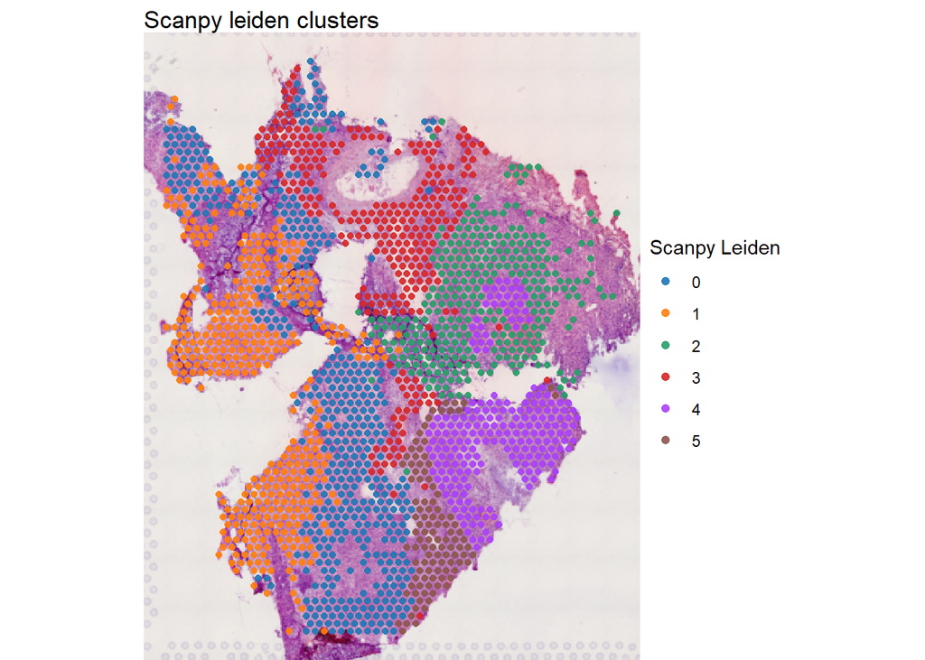

```r
plotSurface(object = spata_obj2,
          color_by = "leiden_gene",
          display_image = TRUE,
          clrp_adjust = leiden_gene_colors,
          pt_size = 1.8) +
  ggplot2::labs(title = "Scanpy leiden clusters", color = "Scanpy Leiden")
```

```r
ggplot2::ggsave('scanpy_leiden.png')
```

## Differential Gene Expression Analysis

This is SPATA2’s built in differential gene expression analysis workflow. We need DE analysis in order to run spata2’s gsea next. Could import scanpy DE, but it is way easier to just run spata2 version than figure out how to transfer this kind of thing from Python workflow to R. - we use the wilcoxon test when running differential expression analysis. - prints an overview of the analysis. - save the results to a dataframe (DeaDf) for future use and save that dataframe as a csv file.

```r
spata_obj2 <-
  runDeAnalysis(object = spata_obj2,
                across = "leiden_gene", # across which identity groups
                method_de = c("wilcox") # with which methods
  )

# get an overview about the de-analysis results stored in your object
print("OVERVIEW OF DEA")
```

```
## [1] "OVERVIEW OF DEA"
```

```r
printDeaOverview(spata_obj2)
```

```
## De-analysis has been performed on grouping variable:
##
## - 'leiden_gene' with methods: wilcox
```

```r
DeaDf <- getDeaResultsDf(object = spata_obj2,
                across = "leiden_gene",
                method_de = "wilcox",
                max_adj_pval = 0.025)
write.csv(DeaDf, paste(directory_10X,"\\",subdir,"\\DeaDf.csv",sep=""),row.names = FALSE)
```

## SPATA2 Gene Set Enrichment Analysis

this is NOT proper gene set enrichment analysis. it is just gene set enrichment. the differentially expressed genes of each cluster are given to [hypeR](https://montilab.github.io/hypeR-docs/) as a character vector of symbols for hypergeometric testing. the authors don’t even use this in their own paper. they use [clusterProfiler](http://yulab-smu.top/biomedical-knowledge-mining-book/clusterprofiler-go.html) `enrichGO` and `enricher` functions (which are also just hypergeometric enrichment, but figuring out actual gsea is going to have to be its own thing I suppose).

# 1. To select genesets that you want to look at:

Set `gene_set_names` parameter in the `runGSEA()` function. `gene_set_names` is a **character vector of gene set names** that are taken from the object’s gene set data.frame. We need to give it a character vector where each value is the name of a geneset. `hypeR` can take msigdb genesets but apparently those can’t pass to the SPATA2 function, so we’ll deal with them later.

This means we need to use SPATA2 `getGeneSetDf(spata_obj2)` to create a dataframe of all the genesets saved to our spata2 object and then filter that dataframe to select the ones we want.

For example, we can set our keyword to be “HM_” `c("HM_")` and filter our gene set df to select all geneset names that include that string. This will select all the msigdb Hallmarks gene signatures. Hallmarks is a good one to pull because we know there are 50 signatures in the collection so it is easy to check and make sure you’re getting what you want.

**Important to note:** We’re pulling these signatures from the spata object, so the names need to be the SPATA2 version of geneset names. They are not the same as the signature name you see in msigdb or in our geneset csv files.

```r
keyword <- c("HM_")
geneset_dataframe <- getGeneSetDf(spata_obj2)
geneset_names <- geneset_dataframe %>%
  filter(str_detect(ont, paste(keyword, collapse = "|"))) %>%
  pull(ont)
geneset_names <- unique(geneset_names)
```

We can also pull a set of signatures we previously added ourselves. For example, here we pull the Neftel, Verhaak, Ravi, Pugh, DAEGs, and SpOT signatures.

```r
keywords_cellstates <- c("Neftel","Verhaak","Pugh","external_Ravi","external_SpOT.upreg","external_SpOT.downreg","external_Ron.upreg","external_Ron.downreg")

geneset_names <- geneset_dataframe %>%
  filter(str_detect(ont, paste(keywords_cellstates, collapse = "|"))) %>%
  pull(ont)
geneset_names <- unique(geneset_names)
```

# 2. Now we run the enrichment analysis across leiden clusters and save results to a dataframe and csv.

```r
#run GSEA
spata_obj2 <-
  runGSEA(
    object = spata_obj2,
    gene_set_names = geneset_names,
    across = "leiden_gene",
    methods_de = "wilcox",
    reduce = FALSE
  )
```

```r
#get GSEA results
gseaDf <- getGseaDf(
  object = spata_obj2,
  across = "leiden_gene",
  method_de = "wilcox"
)
write.csv(gseaDf, paste(directory_10X,"\\",subdir,"\\cellstates_gseaDf.csv",sep=""),row.names = FALSE)
```

# 3. Generate a dotplot to visualize results:

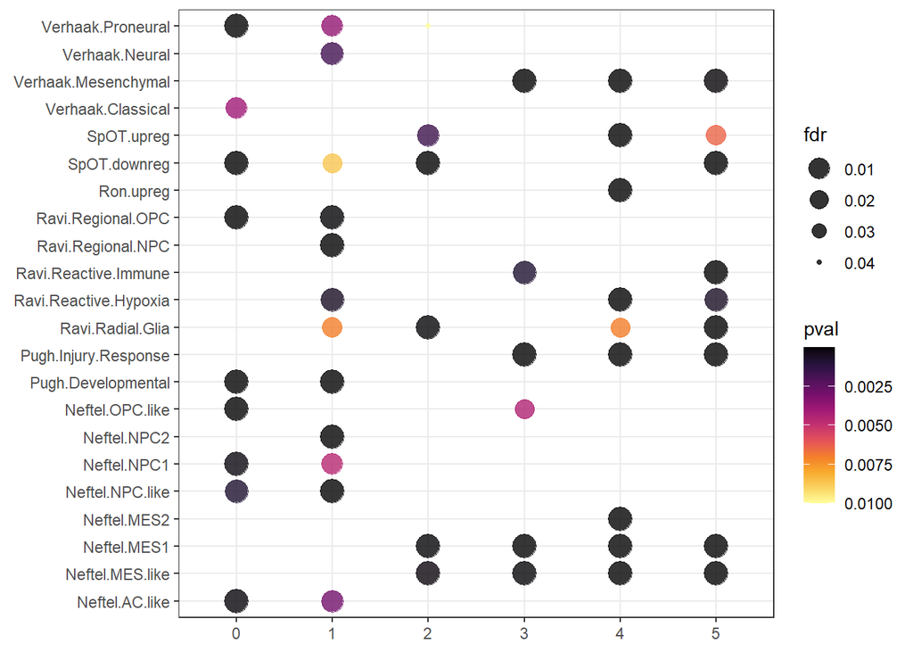

# (Optional) Plot next to leiden cluster surface plot

```r
p2 <-
  plotSurface(object = spata_obj2,
              color_by = "leiden_gene",
              pt_size = 2.2,
              clrp_adjust = leiden_gene_colors,
              display_image = TRUE) +
  ggplot2::labs(color = "Clusters")
```

```
## 17:00:57 Joining and smoothing 1 feature.
```

```
## 17:00:57 Skip smoothing of feature 'leiden_gene' as it is of class 'character'.
```

```
## 17:00:57 Done.
```

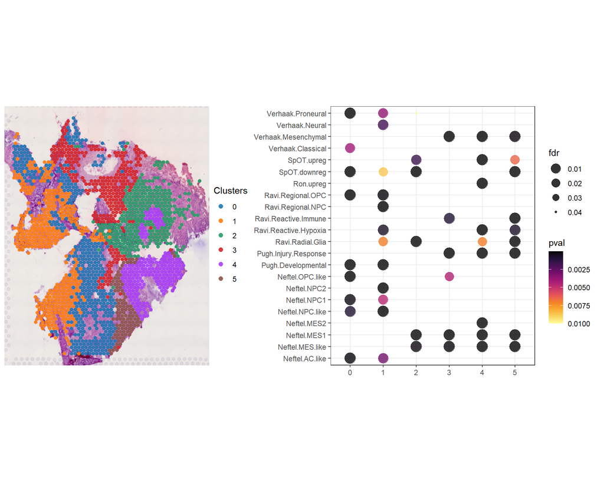

```r
# combine with patchwork
#grid.arrange(p2,p3, ncol = 2)
p2 + legendRight() +
  p3 + legendRight()
ggplot2::ggsave('cluster_GSEAdotplot_cellstates.png')
```

# Heatmap

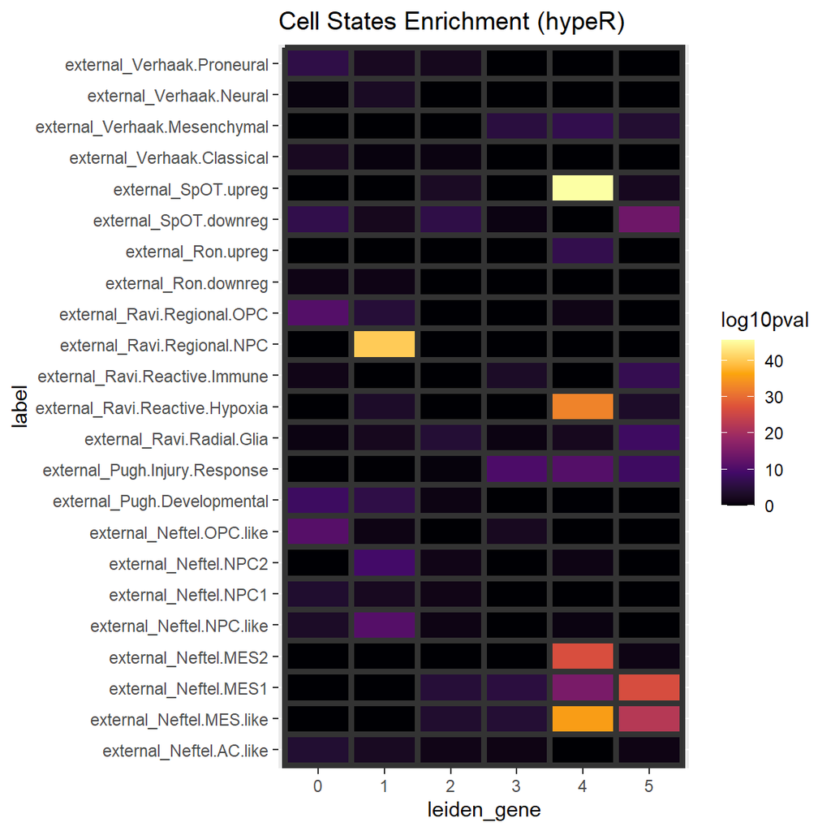

# Now we’re done with the SPATA2 workflows

Probably a good idea to save your spata_obj2 at this point. Differential expression analysis and gene set enrichment will be saved as part of that object.

```r
#Adjust directory instructions for spata object 2
spata_obj2 <-
  adjustDirectoryInstructions(
    object = spata_obj2,
    to = "spata_object",
    directory_new = spata_obj_dir2, # the directory under which to store the object
  )
```

```
## 17:00:59 Default directory to the corresponding spata-object set to 'C:/Users/mzaidi/Documents/Visium Datasets/Sheila_GBM/GBM_datasets/50D/SPATA2_figures/spata_obj2.RDS'.
```

```r
saveSpataObject(object = spata_obj2)#Save SpataObj
```

```
## 17:00:59 Saving spata-object under 'C:/Users/mzaidi/Documents/Visium Datasets/Sheila_GBM/GBM_datasets/50D/SPATA2_figures/spata_obj2.RDS'.
```

```
## 17:01:13 Done.
```

## clusterProfiler enrichment

Neftel and Ravi papers both use clusterProfiler enricher functions to evaluate enriched signatures in their cell state clusters. Here we’re going to do the same thing for our clusters.

Set the organism that you’re working with:

```r
# SET THE DESIRED ORGANISM HERE
organism = "org.Hs.eg.db"
#BiocManager::install(organism, character.only = TRUE)
library(organism, character.only = TRUE)
```

```r
#DeaDf <- getDeaResultsDf(object = spata_obj2,across = "leiden_gene", method_de = "wilcox",max_adj_pval = 0.025)
leidenclusters <- unique(DeaDf$leiden_gene)
ids<-clusterProfiler::bitr(DeaDf$gene, fromType = "SYMBOL", toType = "ENTREZID", OrgDb=organism)
```

```r
#dedup_ids = ids[!duplicated(ids[c("SYMBOL")]),]
DeaDf <- DeaDf[DeaDf$gene %in% ids$SYMBOL,]
map = setNames(c(ids$ENTREZID),c(ids$SYMBOL))
DeaDf$Entrez_ID = map[DeaDf$gene]

#convert to list of lists form
geneList_master <- vector(mode = "list")
for(cluster in leidenclusters){
  geneList <- DeaDf %>%
    filter(leiden_gene==cluster) %>%
    pull(Entrez_ID)
  geneList_master[[cluster]] <- geneList
}
```

Now we need to choose the genesets we want to query for gene set enrichment.

```r
#c2 and c5 from msigdb seem to be a common general pairing
c5 <- msigdbr(species = "Homo sapiens", category = "C5") %>%
                   dplyr::select(gs_name, entrez_gene)
c2 <- msigdbr(species = "Homo sapiens", category = "C2") %>%
  dplyr::select(gs_name, entrez_gene)
c2c5 = rbind(c2, c5)

#c7 is the immune msigdb collection. Too broad though.
c7 <- msigdbr(species = "Homo sapiens", category = "C7") %>%
  dplyr::select(gs_name, entrez_gene)

# we can load our own signatures too. Just have to convert to ENTREZID
external_genesets <- geneset_dataframe %>%
  filter(str_detect(ont, paste(keywords_cellstates, collapse = "|")))
ids <- clusterProfiler::bitr(external_genesets$gene, fromType = "SYMBOL", toType = "ENTREZID", OrgDb=organism)
```

```r
external_genesets <- external_genesets[external_genesets$gene %in% ids$SYMBOL,]
map = setNames(c(ids$ENTREZID),c(ids$SYMBOL))
external_genesets$entrez_gene = map[external_genesets$gene]
external_genesets <- external_genesets %>% dplyr::select(-gene)
```

# MSigDB C2 (curated genesets) and C5 (ontology gene sets) joint enrichment analysis

- C5 includes gene ontology (GO:BP, GO:CC, GO:MF) and human phenotype ontology (HPO) sets
- These are the combined collection of sets that Neftel et al. (2019) used to evaluate pathway enrichment for their cell states. Run enricher across all clusters.
- geneset collection: c2c5

```r
ck <- compareCluster(geneCluster = geneList_master,
                     fun = enricher,
                     TERM2GENE=c2c5,
                     minGSSize = 10,
                     pAdjustMethod = "BH",
                     pvalueCutoff = 0.05,
                     qvalueCutoff = 0.2)
ck <- setReadable(ck, OrgDb = "org.Hs.eg.db", keyType="ENTREZID")

c2c5_df <- ck@compareClusterResult
head(c2c5_df)
```

```
##   Cluster
## 1       0
## 2       0
## 3       0
## 4       0
## 5       0
## 6       0
##                                                                                          ID
## 1                                                           GOBP_GLIAL_CELL_DIFFERENTIATION
## 2                                                      GOBP_OLIGODENDROCYTE_DIFFERENTIATION
## 3                                                              LEIN_OLIGODENDROCYTE_MARKERS
## 4                                                                          GOBP_GLIOGENESIS
## 5 WP_OLIGODENDROCYTE_SPECIFICATION_AND_DIFFERENTIATION_LEADING_TO_MYELIN_COMPONENTS_FOR_CNS
## 6                                                               GOBP_GLIAL_CELL_DEVELOPMENT
##                                                                                 Description
```

[output cut: 27 more lines]

```r
write.csv(ck@compareClusterResult, paste(directory_10X,"\\",subdir,"\\C5C2_enricher.csv",sep=""),row.names = FALSE)
```

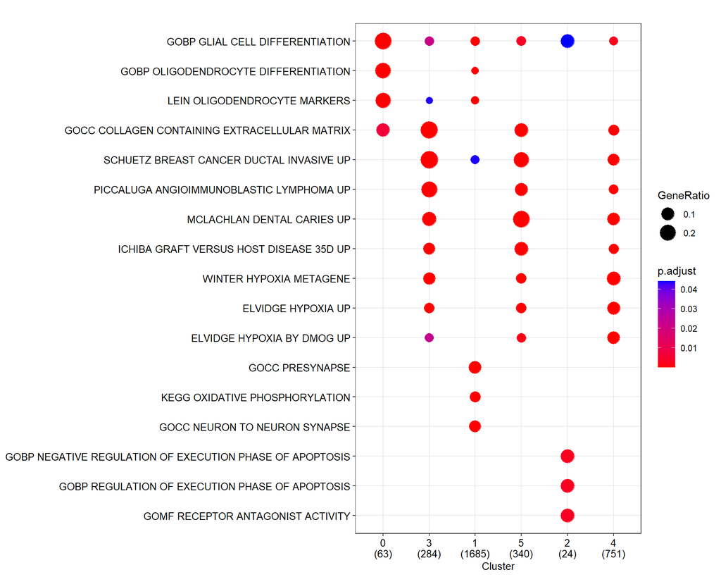

```r
dpc2c5 <- dotplot(ck, font.size = 10,showCategory = 3,label_format = 80)
dpc2c5
```

```r
ggplot2::ggsave('C5C2_dotplot_enricher.png')
```

# barplot

```r
for(cluster in leidenclusters){
  ego <- enrichGO(gene = geneList_master[[cluster]],
                  #universe = genelist_allgenes$ENTREZID,
                  OrgDb = "org.Hs.eg.db",
                  ont = "ALL",
                  keyType = "ENTREZID",
                  pAdjustMethod = "BH",
                  pvalueCutoff  = 0.01,
                  qvalueCutoff  = 0.05,
                  readable = TRUE)
  if(nrow(ego@result)>5){
    # bar plot
    mutate(ego, qscore = -log(p.adjust, base=10)) %>%
      barplot(x="qscore", showCategory=20)
    #ggplot2::ggsave('cnetplot_6.png')
    ggplot2::ggsave(paste(subdir,'/','barplot_',cluster,'.png',sep=''))
  }
}
```

# Heatmap

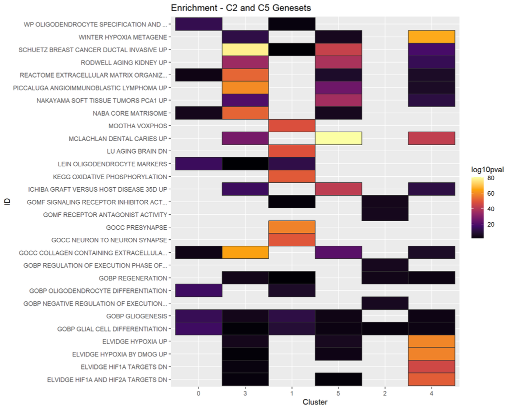

```r
#add -log10(pval)
c2c5_df <- transform(c2c5_df, log10pval = (-1*log10(pvalue)))
#to prep for plotting, take the top 10 genesets for each cluster
c2c5_forhm=NULL
for(cluster in leidenclusters){
  clusterdf <- c2c5_df %>%
    filter(Cluster==cluster)
  clusterdf <- clusterdf[1:5, ]

  c2c5_forhm = rbind(c2c5_forhm,clusterdf)
}
row_names <- unique(dplyr::pull(c2c5_forhm, ID))
c2c5_forhm <- c2c5_df %>%
  filter(ID %in% row_names)

#cut down the genesets names for plotting
c2c5_forhm <- as_tibble(c2c5_forhm)
nameTooLong <- function(ID) {
  case_when(
    nchar(ID) > 40 ~ as.character(gsub("_"," ", str_trunc(ID, 40, "right"))),
      .default = as.character(gsub("_"," ", ID))
  )
}
c2c5_forhm <- c2c5_forhm %>%
  mutate(ID = nameTooLong(ID))

hmc2c5 <- ggplot(c2c5_forhm, aes(Cluster, ID, fill= log10pval)) +
  geom_tile(colour="gray20", linewidth=0.5, stat="identity") +
  scale_fill_viridis_c(option="B",direction = 1,
                       na.value = "white",guide = "colourbar") +
  ggtitle("Enrichment - C2 and C5 Genesets")
hmc2c5
```

```r
ggplot2::ggsave('C5C2_heatmap_enricher.png')
```

# MSigDB C7 (immuneSigDB)

These are experimental immune sets. Need a more curated collection.

# Our imported cell states/hypoxia signatures

The same ones we got from our SPATA2 object.

# Dotplot

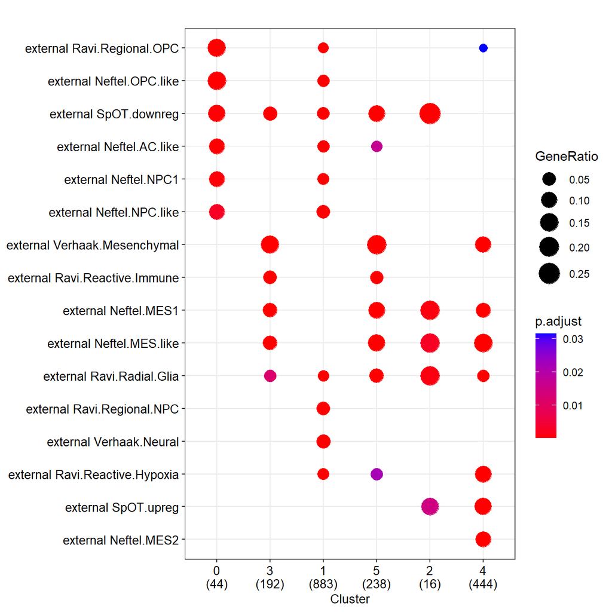

# Heatmap

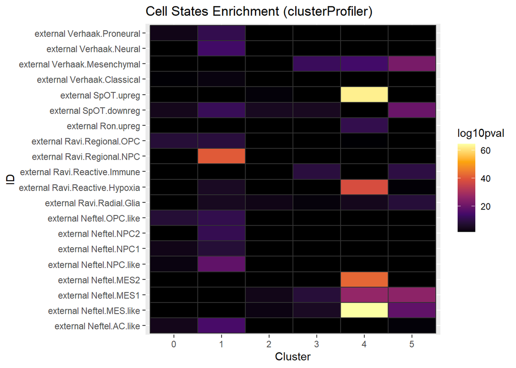